# 全球平均气温时间序列分析

齐玥3120319078

2021年3月24日

# 1 数据描述

全球气候变化对自然生态系统和经济社会的影响正在日益凸显，全球气候风险持续上升。世界经济论坛发布的《全球风险报告2020》指出，到本世纪末，全球气温有望至少上升3摄氏度，是气候专家警告的两倍气候变化。相关的热带气旋、高温热浪、干旱等极端天气与气候事件的频发，以及气候政策无法达到预期等环境风险日益突出并将继续发展，未来气候将持续变暖并可能造成全球风险加剧，引发系统性风险的改变，对全球发展造成深远影响。

本文从NOAA网站获取了1948年1月至2019年7月的月度全球平均气温数据（华氏度），将其转换成时间序列数据（摄氏度），并对该时间序列做平稳性检验和建模。

数据来源：https://www.psl.noaa.gov/data/climateindices/。

```r
data <- read.csv("C:\\Users\\12786\\Desktop\\data.csv")
temperature <- ts((data$temperature-32)/1.8,start=c(1948,1),frequency = 12)
n = length(temperature)
print(n)
```

```
## [1] 859
```

```r
start(temperature)
```

```
## [1] 1948    1
```

```r
end(temperature)
```

```
## [1] 2019    7
```

# 2 时间序列图

下面画了全球平均气温的时间序列图和时间序列分解图，后者分解出了时间序列的趋势效应、季节效应和随机效应，并将其和原始观察序列画在一起。

下面两张图表明，全球平均气温呈现上升的趋势，从1950年的-20摄氏度上升到2019年的30度左右，这是全球气候变暖的直接证据。此外，全球平均气温存在明显的季节效应。地球公转使各个季节地球离太阳的角度距离不同，所以一年内夏季温度高，冬季温度低，从而使气温呈现季节效应。

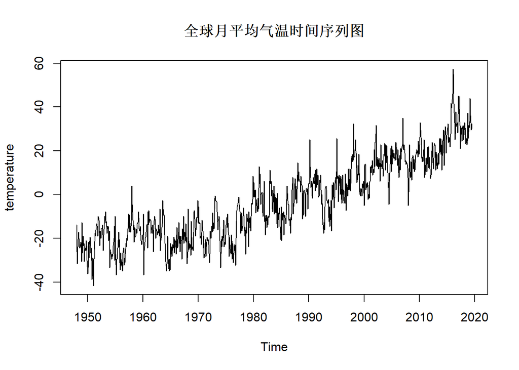

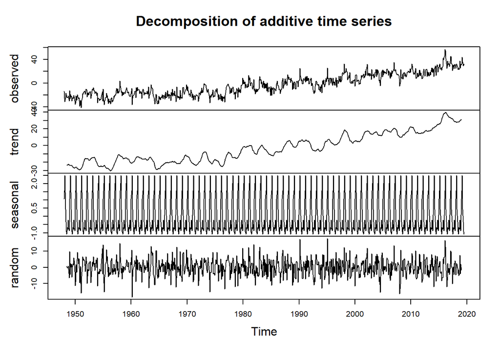

# 3 平稳性检验

时间序列图表明全球平均气温均值不为0，且有明显的趋势，因此时间序列不平稳。下面对原始数据差分，并重新画时间序列图。

由时间序列可以看出差分后的全球平均气温在0附近波动，且无明显趋势和季节效应。下一步对差分后的时间序列做单位根检验(ADF test)，发现检验统计量Dickey-Fuller值为-12.856，对应的p值为0.01<0.05，拒绝原假设，说明在5%的显著性水平下有充分的证据表明该时间序列平稳。

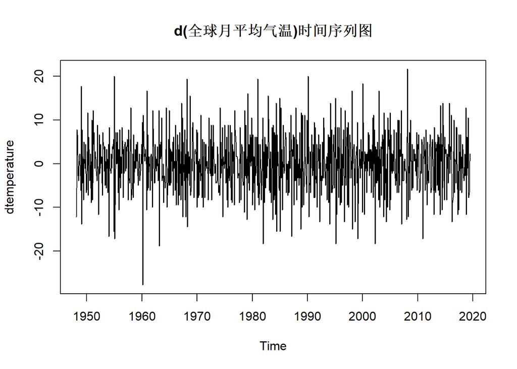

```r
dtemperature <- diff(temperature)
plot.ts(dtemperature,main="d(全球月平均气温)时间序列图")
library(tseries)
```

```r
adf.test(dtemperature)
```

```
##
##  Augmented Dickey-Fuller Test
##
## data:  dtemperature
## Dickey-Fuller = -12.856, Lag order = 9, p-value = 0.01
## alternative hypothesis: stationary
```

```r
mean(dtemperature)
```

```
## [1] 0.05374255
```

# 4 平稳时间序列建模

## 4.1 ACF和PACF图

结果表明，自相关系数在滞后4阶后始终在置信区间内，呈现截尾。而偏自相关系数则不规则地波动，呈现拖尾。从ACF和PACF图可以初步推断，差分后的全球平均气温服从MA(4)模型。

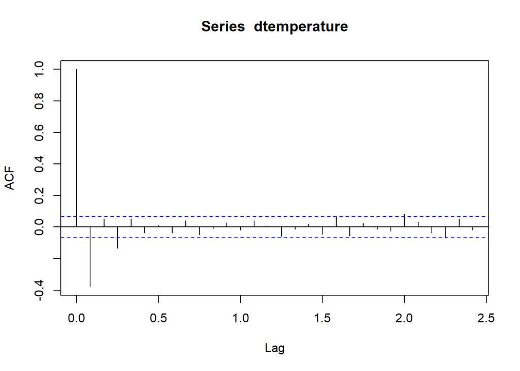

```r
acf(dtemperature)
```

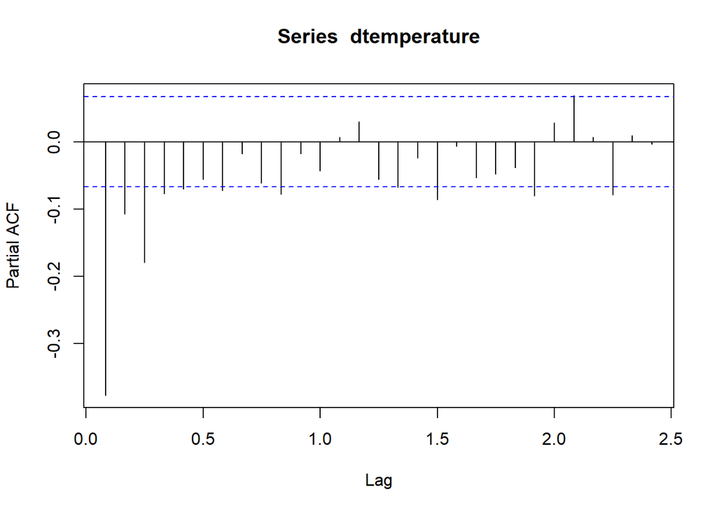

```r
pacf(dtemperature)
```

## 4.2 Bartlett公式

MA模型自相关系数截尾。由Bartlett公式可知，当k>q且N充分大时，自相关系数的分布为渐进正态分布，即$\rho_k \asymp N(0,\frac 1 N(1+2\sum_{l=1}^q\rho_l^2))$。

因此，若存在q使得$p=P(|\rho_k|)\le \frac{2}{\sqrt{n}}\sqrt{1+2\sum_{l=1}^q\rho_l^2}=95.45\%$，则该平稳时间序列服从MA(q)模型。

下文编写了bartlett.ma(data,n,q)函数，输入平稳时间序列data和待检验的MA模型阶数q，输出上述公式的概率p。

通过拟合1-4阶的MA模型，本文发现MA(1)和MA(2)模型的概率p为93.33%<95.45%。而从MA(3)到MA(4)模型的概率p为96.67%>95.45%，此时原假设成立，说明MA模型至少为MA(3)。

通过ACF和PACF图，本文认为平稳时间序列服从MA(4)，而通过渐进分布本文判断平稳时间序列至少为MA(3)。下文则对模型为MA(3)还是MA(4)进行进一步探讨。

```r
#输入平稳时间序列data、MA模型阶数q，输出概率
bartlett.ma <- function(data, q){
  #先求k=1,2,...,q,q+1,...,q+M的自相关系数cor.vec
  cor.vec <- c()
  n <- length(data)
  M <- ceiling(n^0.5)
  for(i in 1:(q+M)){
    cor.n <- cor(data[1:(n-i)],data[(1+i):n])
    cor.vec <- c(cor.vec, cor.n)
  }
  #求渐进正态分布的标准差std
  std <- 1/n^0.5*(1+2*sum(cor.vec[1:q]^2))^0.5
  #求自相关系数的绝对值<=标准差的概率p
  cnt <- 0
  for (j in (q+1):(q+M)){
    if(abs(cor.vec[j])<=2*std){
      cnt = cnt + 1
    }
  }
  p <- round(cnt/M,4)
  return(p)
}
paste(bartlett.ma(dtemperature,1),bartlett.ma(dtemperature,2),bartlett.ma(dtemperature,3),bartlett.ma(dtemperature,4))
```

```
## [1] "0.9333 0.9333 0.9667 0.9667"
```

## 4.3 残差方差图

下文编写了拟合平稳时间序列MA(2)模型的最小二乘估计函数ols.ma2，其中残差方差由$\hat\sigma_a^2=\frac{RSS}{n-q}=\frac{\sum_{t=1}^n(Y_t-\hat Y_t)^2}{n-q}$计算得到。

为了计算残差，本文对MA模型进行最小二乘估计。具体思路如：

- 假定真实模型为$Y_t=a_t-\theta_1 a_{t-1}-\theta_2 a_{t-2}$。
- 给定之前的扰动项，当期扰动项可以表示成$a_t=Y_t+\theta_1a_{t-1}+\theta_2a_{t-2}$。
- 令$a_{-1}=a_0=0$，可以得到$a_1=Y_1, a_2=Y_2+\theta_1a_1,...,a_n=Y_n+\theta_1a_{n-1}+\theta_2a_{n-2}$。
- 在可逆范围(-1,1)内搜索使误差平方和最小的参数$\theta_1, \theta_2$。

此处应注意时间序列模型中的扰动项是无法直接观测到的，无法用经典线性回归中正规方程组的方式计算。

```r
#最小二乘法估计MA(2)模型，输入ma模型参数步长，输出系数和残差方差
ols.ma2 <- function(data,by1, by2){
  min.resid.sq <- 100000000
  mu <- mean(data)
  coef <- c()
  for(theta1 in seq(-0.9999,0.9999,by=by1)){
    for(theta2 in seq(-0.9999,0.99999,by=by2)){
      resid.sq <- 0
      ai <- rep(0,2) #conditional on a_0=a_{-1}=0
      for(i in 1:(n-1)){
        aj <- mu + data[i]+theta1 * ai[1] + theta2 * ai[2]
        resid.sq = resid.sq + aj^2
        ai <- c(ai[2],aj)
      }
      if(resid.sq<min.resid.sq){
      min.resid.sq = resid.sq
      coef = c(theta1, theta2, mu)
      }
    }
  }
  result <- c(coef,min.resid.sq/(length(data)-3))#有常数项，因此-3
  return (round(result,4))
}

ols.ma2(dtemperature,0.02,0.02)
```

[output not shown]

```r
arima(dtemperature,c(0,0,2))
```

```
##
## Call:
## arima(x = dtemperature, order = c(0, 0, 2))
##
## Coefficients:
##           ma1      ma2  intercept
##       -0.4861  -0.0769     0.0617
## s.e.   0.0330   0.0343     0.0915
##
## sigma^2 estimated as 37.49:  log likelihood = -2772.38,  aic = 5552.76
```

在搜索更高维的参数空间时，由于最小二乘估计的时间复杂度过大$O(NM^q),M$为每轮迭代次数，此处不再采用最小二乘法估计MA(3)及更高阶的模型，而是用arima函数用BFGS迭代法估计MA(q)模型的系数并得到拟合后的残差值。

下文写了计算残差方差的函数iter.resid和残差方差图的函数resid.plot。我们得到MA(3)模型的残差方差为36.691，MA(4)模型的残差方差为36.732，MA(3)模型更小。

从滞后10阶的残差方差图，可以看到随着滞后阶的增加，模型的残差方差始终下降，仅在MA(4)和MA(10)模型处略有上升。

```r
#输入平稳时间序列data、MA模型滞后阶数model.lag，输出残差方差
iter.resid <- function(data,model.lag){
  m <- arima(data, c(0,0,model.lag))
  resid.a <- (sum((m$residuals)^2))/(n-model.lag)
  return(round(resid.a,4))
}

#计算MA(3)和MA(4)模型的残差方差
resid.ma3 <- iter.resid(dtemperature,3)
resid.ma4 <- iter.resid(dtemperature,4)
paste(resid.ma3, resid.ma4)
```

```
## [1] "36.6913 36.7319"
```

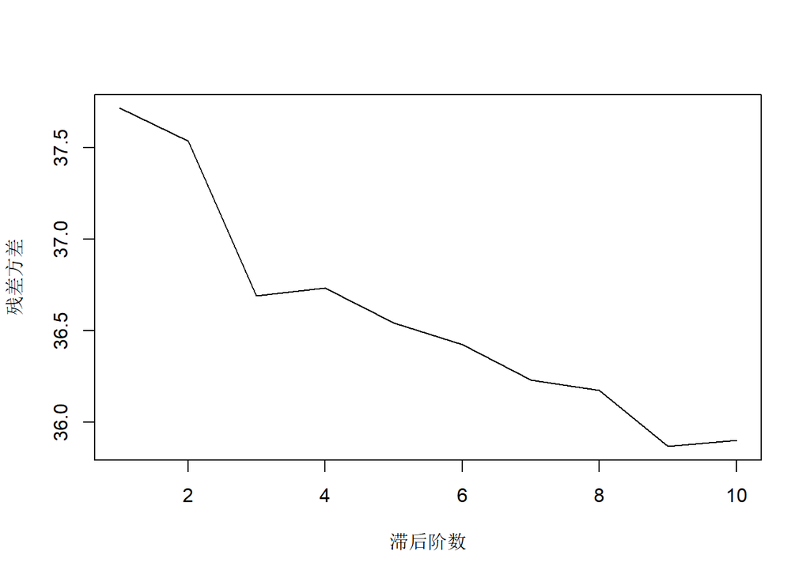

```r
#输入平稳时间序列data、残差方差图的最大滞后阶数max.lag，输出残差方差图
resid.plot <- function(data,max.lag){
  resid <- c() #残差方差
  q <- c() #MA模型阶数
  for(i in 1:max.lag){
    q <- c(q, i)
    resid.a <- iter.resid(data,i)
    resid <- c(resid, resid.a)
  }

  return(plot(q,resid,type='l',xlab="滞后阶数", ylab = paste("残差方差")))
}

resid.plot(dtemperature,10)
```

## 4.4 最佳准则函数

下文以AIC为最佳准则函数判断MA模型阶数，其中$AIC(q)=ln\hat \sigma_a^2(q)+2\frac qN$。

先计算了MA(3)和MA(4)模型的AIC，得到MA(3)的AIC为3.610，MA(4)的AIC为3.613，MA(3)模型更小。随后画了滞后1-10阶的MA模型的AIC，发现比残差房差图的轮廓更清晰。在加上对参数个数的惩罚项后，各MA模型的优劣得到更好地区分。

```r
aic.ma3 <- log(resid.ma3)+2*3/length(dtemperature)
aic.ma4 <- log(resid.ma4)+2*4/length(dtemperature)
paste(aic.ma3, aic.ma4)
```

```
## [1] "3.60953267673032 3.61296959664971"
```

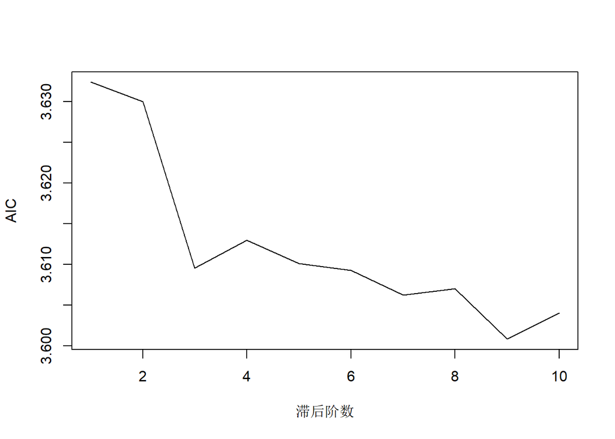

```r
#输入平稳时间序列data、残差方差图的最大滞后阶数max.lag，输出不同阶数模型的AIC图
aic.plot <- function(data,max.lag){
  aic.vec <- c() #模型AIC
  q <- c() #MA模型阶数
  for(i in 1:max.lag){
    q <- c(q, i)
    resid.a <- iter.resid(data,i)
    aic <- log(resid.a)+2*i/length(data)
    aic.vec <- c(aic.vec, aic)
  }
  return(plot(q,aic.vec,type='l',xlab="滞后阶数", ylab = paste("AIC")))
}

aic.plot(dtemperature,10)
```

```r
round(arima(dtemperature, c(0,0,3))$coef,4)
```

```
##       ma1       ma2       ma3 intercept
##   -0.4775   -0.0293   -0.1640    0.0623
```

# 5 结论与不足

全球气候变暖会不仅危害自然生态系统的平衡，还会威胁人类的生存。本文对全球平均气温进行时间序列分析，发现其呈现逐年上升的趋势，从1950年的-20摄氏度上升到2019年的30度左右，全球气候变暖并不是危言耸听。除去趋势效应，全球平均气温也呈现明显的季节效应，原始时间序列不平稳。在对其差分后，对差分的序列进行ADF检验，发现差分后的时间序列平稳。

第二，本文通过残差方差图对MA模型定阶，写了MA(2)模型的最小二乘估计方法，用arima函数计算了不同阶数MA模型的残差，并进一步计算残差方差。本文发现，$\hat\sigma_a^2(3)=36.691<\hat\sigma_a^2(4)=36.732$，滞后10阶以内的MA模型的残差方差始终呈现下降趋势。

第三，本文计算了MA模型的AIC，得到$AIC(3)=3.610<AIC(4)=3.613$。

经过上述分析，本文认为MA(3)模型能最好地拟合差分后的全球平均气温，最终得到的模型为：

$$\begin{align*}
dtemp_t=0.062+a_t-0.478a_{t-1}-0.029a_{t-2}-0.164a_{t-3}
\end{align*}$$

本文的对于高阶MA模型的求解采取了调包的方式，下一步可以学习非线性方程组的求解和常见的优化算法。